# P/BIO381 Tutorials: Population Genomics Day 5

November 01, 2021 (whaaat?)

# Learning Objectives

1. Evaluate the overlap between chromosomal regions with evidence of selective sweeps and levels of genetic divergence (Fst) between species
2. Learn to work with Genomic Ranges and extract genome annotation
3. Test for functional enrichment of candidate genes

## Reviewing where we left off last time:

We (hopefully) have produced the following for each of our chromosomes:

- RAiSD tests for selective sweeps
- Fst in sliding windows of 50 kb (*oops – need to update the ggplot titles!*)
- Nucleotide diversity in sliding windows of 50 kb (*ditto!*)

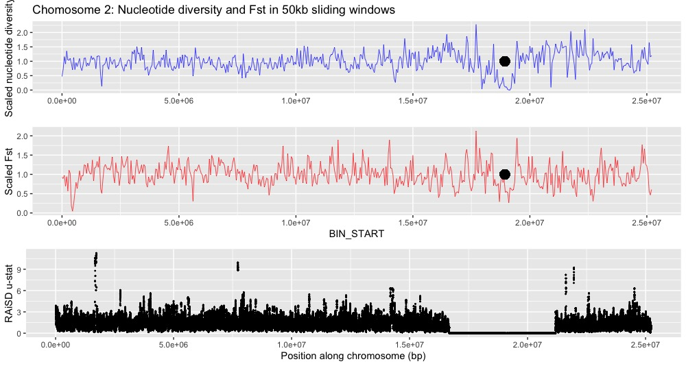

We zoomed in on a couple of interesting regions that showed evidence for selective sweeps (based on the Manhattan plots of the RAiSD u-stat). For example, here’s Chr02 zoomed in on that first RAiSD peak:

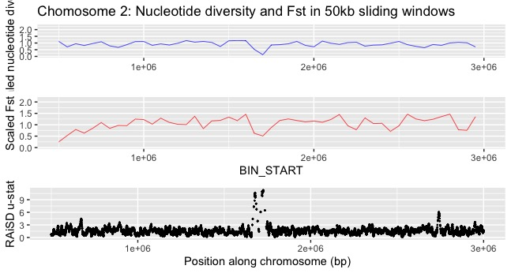

Right now we’re just eye-balling it. How can we get a test for association between RAiSD sweep regions and regions of low Fst?

## Enter the GenomicRanges() R package

GenomicsRanges is a very versatile R package for defining feature sets in genomic data (defined by ranges, in bp) and looking for overlaps between different sets.

Note, you’ll need to uncomment the first few lines if you don’t have GenomicRanges and GenomicFeatures installed already.

```
# if (!requireNamespace("BiocManager", quietly = TRUE))
#   install.packages("BiocManager")
# BiocManager::install("GenomicRanges")
# BiocManager::install("GenomicFeatures")

library(GenomicRanges)
library(GenomicFeatures)
```

Here’s our workflow:

1. Bring in the Fst outputs we generated last week and identify windows with low Fst
2. Bring in the RAiSD outputs and identify very high values of the u-stat (candidates for selection)
3. Use GenomicRanges() to find their overlaps
4. Test for significance by randomizing the values of meanFst among the windows many times, and estimate how much overlap there is in the randomized distribution

### Step 1: Import Fst and threshold for low values

```
####### Randomization test for Fst and sweep outliers #########

setwd("~/OneDrive - University of Vermont/PBIO381/Fall2021/Module3_PopLandscapeGenomics/") # Customize to where your Fst, Pi, and RAiSD files are located on your laptop

fst <- read.table("Selection/Bals_Tricho_All.windowed.weir.fst", sep="\t",header=T) # Import the Fst results

cent <- read.table("Selection/Chr02_centromere.txt", sep="\t",header=F) # Import the centromere coordinates

fst <- fst[-which(fst$BIN_START>cent$V2 & fst$BIN_END<cent$V3),] # Mask Fst windows in the centromere region


# Calculate Genomic Ranges for outlier bins

CHR="Chr02"  # Customize to your chromosome.  Make sure syntax is exact!

# Define the genomic ranges of the Fst bins
fstGR <- GRanges(CHR,IRanges(fst[,"BIN_START"],fst[,"BIN_END"]))

# Define what should be a "low" value of Fst.  Here, we'll try the lowest 10% of windows that don't incude the centromere.  Can play with this if you want (choosing the last value in the quantile function call).
fstThreshold = quantile(fst$MEAN_FST,0.1)

# Call outliers (=1) or non-outliers (=2) based on fst Threshold
fstGR$outlier <- ifelse(fst$MEAN_FST<fstThreshold,1,2)

# Grab just the outlier Fst windows
fstCand <- subset(fstGR, outlier==1)
```

### Step 2: Import RAiSD and threshold for candidate sweeps

```
raisd <- read.table(paste0("Selection/RAiSD_Report.",CHR,".",CHR), sep="\t",header=F) # Import the RAiSD results

# Define RAiSD genomic ranges based on first and last SNP within the RAiSD windows of 50 SNPs each.   How deos this relate to the Fst window size?
raisdGR <- GRanges(CHR,IRanges(raisd[,2],raisd[,3]))

# Define RAiSD outliers, based on the upper 1% of SNPs
raisdThreshold = quantile(raisd$V7,0.99)

raisdGR$outlier <- ifelse(raisd$V7>raisdThreshold,"outlier","non")
```

Since the RAiSD results are 1 per SNP, and adjacent SNPs have highly similar values (because of linkage), we want to merge runs of adjacent outlier positions together into outlier windows.

```
raisdGR_out <- unlist(reduce(split(raisdGR, ~outlier)))
raisdGR_out$outlier <- names(raisdGR_out)
raisdCand <- subset(raisdGR_out, outlier=="outlier")
```

### Step 3: Find the overlaps betweeen low Fst windows and high RAiSD windows

```
# Use GenomicRanges to pull out the RAiSD outlier windows that overlap the lowest Fst windows
overlap <- subsetByOverlaps(raisdCand, fstCand)

length(overlap) # Number of the RAiSD sweep candidate loci that overlap with the lowest n% of Fst windows
```

How many windows overlap between RAiSD and Fst?

*How much is a lot? How few is a little?*

### Step 4: Test for significance of observed overlapping bins by randomizing the Fst values and recalculting the overlap

```
# A little code I wrote to permute Fst values randomly among the 50kb windows, and re-calculate the overlap with the RAiSD outliers.
# Can set number of permutation replicates (NumPerm)
# 1000 permutations seems to give a decent randomized distribution

NumPerm=1000

Perm = NA
for(i in 1:NumPerm){
  FstSamp = cbind(fst[,c(2,3)], fst[sample(nrow(fst)),6])
  names(FstSamp) = c("Start", "Stop", "FST")
  FstRand = FstSamp[which(FstSamp[3]<fstThreshold),]
  FstRand_ranges <- GRanges(seqnames=CHR, ranges=IRanges(FstRand[,1],FstRand[,2]))
  FstRand_ranges_red <- reduce(FstRand_ranges)
  Perm[i] = sum(countOverlaps(raisdCand, FstRand_ranges_red))
}

# Plot the random distribution with a blue line marking the observed overlap
hist(Perm, col="gray", main="Randomization test", xlab="Overlapping windows of Fst and RAiSD outliers")
abline(v=length(overlap), col="blue", lwd=3)

# Calculate the p-pvalue based on the rank of the observed value in the randomized distirbution.
# Note the 1-tailed test here (alpha = 0.05)

p_value = 1-ecdf(Perm)(length(overlap))
p_value
```

## Now let’s grab the poplar genome annotation to figure out which genes are in the overlapping lowFst/highRAiSD windows

For this, we’ll need to download from the server a copy of the poplar GFF file. The GFF format is the standard for storing information on genomic feature intervals, like the start and stop of transcripts, exons, introns, UTRs, etc.

Download a copy of the file from the server using Fetch, WinSCP, or `scp` at the commandline:

`/data/project_data/PopGenomics/Annotation/Ptrichocarpa_533_v4.1.gene.gff3.gz`

Once it’s on your laptop, we’ll need to import it to R and create a transcript database (txdb) using the `makeTxDbFromGFF` function.

```
# Import the GFF annotation file and make a transcript database
txdb <- makeTxDbFromGFF("Annotation/Ptrichocarpa_533_v4.1.gene.gff3.gz", format="gff3")

txdb

# How many chromosomes are present?
head(seqlevels(txdb))

# Subset the database for just your chromosome of interest
seqlevels(txdb) <- CHR # subset for just your chromosome

# Reduce the transcript database to just the non-redundant gene names, instead of multiple entries for all the variant transcript types per gene
genes <- unlist(reduce(transcriptsBy(txdb, by="gene")))
genes$geneID <- names(genes)
```

Now we’ll use GenomicRanges() just like before to find the genes that overlap in the intervals of our candidate regions of overlapping lowFst/highRAiSD

```
candGenes <- subsetByOverlaps(genes, overlap)

write.table(candGenes$geneID, paste0("Annotation/candGenes",CHR,".txt"), quote=F, col.names=F, row.names=F, sep=",")
```

## Functional enrichment analysis

Now let’s see if there is evidence of functional enrichment for these sets of genes in our candidate regions for selection.

There’s several (many!) ways of approaching this problem, but for today we’ll try the user-friendly Fisher’s Exact Test available at Popgenie.org.

You’ll need to open up your text file of candidate genes that you exported above, copy the list, and then make a new “active” gene list on Popgenie.

Once you’ve got your candidate genes in a new list on Popgenie, go to `Analysis Tools > Enrichment`